# STAT 118: Interactive Data Visualization

### Figure 2: Frequency of Observed Squirrel Behaviors

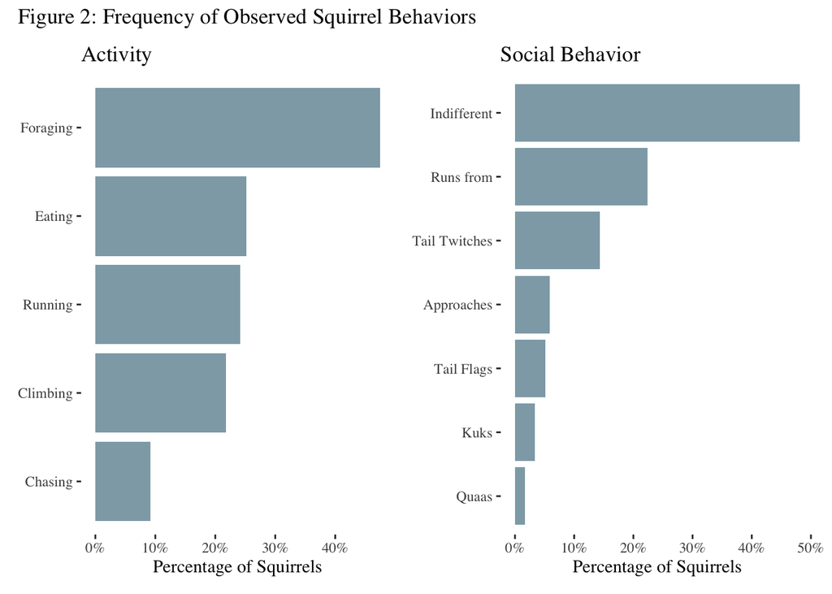

```r
library(ggthemes)

plot1 <- squirrels_lc_in |>
  st_drop_geometry() |>
  select(running, chasing, climbing, eating, foraging) |>
  pivot_longer(everything(),
               names_to = "behavior",
               values_to = "observed") |>
  mutate(behavior = snakecase::to_title_case(behavior)) |> # Fixed my axis labels to look nicer
  group_by(behavior) |> # want to due calc within each behavior
  summarize(pct = mean(observed, na.rm = TRUE)) |> #calculate % squirrels showing behavior
  ggplot(aes(x = reorder(behavior, pct), y = pct)) +
  geom_col(fill = "#8FA9B5") + # the behavior is binary so bars are my only option really
  coord_flip() + # swap the location of the x and y, just being fancy, you can just swap them in aes()
  scale_y_continuous(labels = scales::label_percent()) + # use the scales package for pretty labels
  labs(x = NULL,
       y = "Percentage of Squirrels",
       title = "Activity") +
  theme_tufte()

plot2 <- squirrels_lc_in |>
  st_drop_geometry() |>
  select(kuks, quaas, tail_flags, tail_twitches,
         approaches, indifferent, runs_from) |>
  pivot_longer(everything(),
               names_to = "behavior",
               values_to = "observed") |>
  mutate(behavior = snakecase::to_title_case(behavior)) |>
  group_by(behavior) |>
  summarize(pct = mean(observed, na.rm = TRUE)) |>
  ggplot(aes(x = reorder(behavior, pct), y = pct)) +
  geom_col(fill = "#8FA9B5") +
  coord_flip() +
  scale_y_continuous(labels = scales::label_percent()) +
  labs(x = NULL,
       y = "Percentage of Squirrels",
       title = "Social Behavior") +
  theme_tufte()


library(patchwork)
# Combine into one figure
(plot1 | plot2) +
  plot_annotation(title = "Figure 2: Frequency of Observed Squirrel Behaviors",
                  theme = theme_tufte())
```

Before taking my analysis further, I want basic information about which behaviors are the most frequent. I want to examine the distribution of road proximity (and other factors, but I’m starting with roads) within each behavior. Rarely observed behaviors may not provide enough data and frequently observed behaviors might be too frequently observed to show aany difference (all squirrels are doing this behavior all of the time regardless of where they are).

The most frequent activity squirrels are observed engaging in is foraging. An approximately equal percent of squirrels are observed eating, running, and climbing, with chasing as the least observed behavior. The most frequently observed social behavior is indifference, which tracks. Kuks, quaas, and tail flags are the least frequently observed social behaviors. I can’t really assign any meaning to this. I’m mostly trying to get context for the analysis I really want to do, and I think behavioral frequency is important context.